# Содержание

- 1-Обзор данных
- 2-Предобработка данных
  - 2.1-Переименование столбцов
  - 2.2-Изменение типов данных
  - 2.3-Обработка явных дубликатов
  - 2.4-Обработка неявных дубликатов
- 3-Исследовательский анализ данных
  - 3.1-Статистический анализ данных в ferma_main
  - 3.2-Статистический анализ данных в ferma_dad
  - 3.3-Статистический анализ данных в cow_buy
  - 3.4-Корреляционный анализ признаков в good_ferma_main
- 4-Обучение линейной регрессии
  - 4.1-Обучение первой модели линейной регрессии
  - 4.2-Обучение второй модели линейной регрессии
  - 4.3-Обучение третьей модели линейной регрессии
  - 4.4-Сравнение качества трёх моделей линейной регрессии
- 5-Обучение логистической регрессии
- 6-Общий вывод

# Линейные модели в машинном обучении

**Цель исследования** — создать две прогнозные модели для отбора бурёнок в поголовье для владельца молочного хозяйства «Вольный луг»:

1. Первая модель будет прогнозировать возможный удой коровы (целевой признак — `удой`);
2. Вторая модель будет рассчитывать вероятность получить вкусное молоко от коровы (целевой признак — `вкус молока`).

С помощью моделей нужно отобрать коров по двум критериям:

- Средний удой за год — не менее 6 000 кг;
- Молоко должно быть вкусным.

**Описание данных**

В ходе исследования будут использованы данные ассоциации пастбищ «ЭкоФерма». Информация содержится в **3** датасетах:

- `ferma_main.csv`
- `ferma_dad.csv`
- `cow_buy.csv`

Файл `ferma_main.csv` содержит данные о стаде фермера на текущий момент:

- `id` — уникальный идентификатор коровы;
- `Удой, кг` — масса молока, которую корова даёт в год (в килограммах);
- `ЭКЕ (Энергетическая кормовая единица)` — показатель питательности корма коровы;
- `Сырой протеин, г` — содержание сырого протеина в корме (в граммах);
- `СПО (Сахаро-протеиновое соотношение)` — отношение сахара к протеину в корме коровы;
- `Порода` — порода коровы;
- `Тип пастбища` — ландшафт лугов, на которых паслась корова;
- `порода папы_быка` — порода папы коровы;
- `Жирность,%` — содержание жиров в молоке (в процентах);
- `Белок,%` — содержание белков в молоке (в процентах);
- `Вкус молока` — оценка вкуса по личным критериям фермера, бинарный признак (вкусно, не вкусно);
- `Возраст` — возраст коровы, бинарный признак (`менее_2_лет`, `более_2_лет`).

Файл `ferma_dad.csv` хранит имя папы каждой коровы в стаде фермера:

- `id` — уникальный идентификатор коровы;
- `Имя Папы` — имя папы коровы.

Файл cow_buy.csv содержит данные о коровах «ЭкоФермы», которых фермер хочет изучить перед покупкой:

- `Порода` — порода коровы;
- `Тип пастбища` — ландшафт лугов, на которых паслась корова;
- `порода папы_быка` — порода папы коровы;
- `Имя_папы` — имя папы коровы;
- `Текущая_жирность,%` — содержание жиров в молоке (в процентах);
- `Текущий_уровень_белок,%` — содержание белков в молоке (в процентах);
- `Возраст` — возраст коровы, бинарный признак (`менее_2_лет`, `более_2_лет`).

**Ход исследования**

Исследование пройдёт в 4 этапа:

1. Обзор данных.

Ознакомимся с основными характеристиками и структурой данных.

2. Предобработка данных.

Выявим и устраним возможные проблемы в данных: явные и неявные дубликаты, некорректные типы данных.

3. Исследовательский анализ данных.

Проведём статистический анализ для выявления и устранения возможных выбросов и аномалий, а также корреляционный анализ для поиска взаимосвязей между признаками.

4. Обучение прогнозных моделей.

Обучим модели линейной и логистической регрессии для поиска целевых признаков `удой` и `вкус молока`.

## Обзор данных

Считаем CSV-файлы и загрузим данные в датафреймы pandas:

```python
# импортируем все необходимые библиотеки для анализа данных и визуализации
import pandas as pd
import matplotlib.pyplot as plt
import numpy as np
import seaborn as sns
import phik

# импортируем классы для обучения моделей
from sklearn.linear_model import LinearRegression
from sklearn.linear_model import LogisticRegression
from sklearn.model_selection import train_test_split
from sklearn.preprocessing import OneHotEncoder
from sklearn.preprocessing import StandardScaler

# импортируем метрики для оценки качества моделей
from sklearn.metrics import r2_score
from sklearn.metrics import accuracy_score
from sklearn.metrics import recall_score
from sklearn.metrics import precision_score
from sklearn.metrics import confusion_matrix
from sklearn.metrics import mean_squared_error
from sklearn.metrics import mean_absolute_error
```

```python
# сохраним в переменную ссылку на первый датафрейм - ferma_main
ferma_main = pd.read_csv('https://code.s3.yandex.net/datasets/ferma_main.csv', sep=';')
```

```python
# сохраним в переменную ссылку на второй датафрейм - ferma_dad
ferma_dad = pd.read_csv('https://code.s3.yandex.net/datasets/ferma_dad.csv', sep=';')
```

```python
# сохраним в переменную ссылку на третий датафрейм - cow_buy
cow_buy = pd.read_csv('https://code.s3.yandex.net/datasets/cow_buy.csv', sep=';')
```

Выведем первые строки каждого датафрейма:

```python
# выведем первые 20 строк датафрейма
ferma_main.head(20)
```

|  | id | Удой, кг | ЭКЕ (Энергетическая кормовая единица) | Сырой протеин, г | СПО (Сахаро-протеиновое соотношение) | Порода | Тип пастбища | порода папы_быка | Жирность,% | Белок,% | Вкус молока | Возраст |
| --- | --- | --- | --- | --- | --- | --- | --- | --- | --- | --- | --- | --- |
| 0 | 1 | 5863 | 14,2 | 1743 | 0,89 | Вис Бик Айдиал | Равнинное | Айдиал | 3,58 | 3,076 | вкусно | более_2_лет |
| 1 | 2 | 5529 | 12,8 | 2138 | 0,89 | Вис Бик Айдиал | Равнинные | Соверин | 3,54 | 3,079 | вкусно | менее_2_лет |
| 2 | 3 | 5810 | 14 | 1854 | 0,885 | РефлешнСоверинг | Холмистое | Соверин | 3,59 | 3,074 | не вкусно | более_2_лет |
| 3 | 4 | 5895 | 12,4 | 2012 | 0,885 | РефлешнСоверинг | Холмистое | Айдиал | 3,4 | 3,075 | не вкусно | более_2_лет |
| 4 | 5 | 5302 | 12,8 | 1675 | 0,885 | Вис Бик Айдиал | Равнинные | Соверин | 3,73 | 3,073 | вкусно | менее_2_лет |
| 5 | 6 | 5254 | 12,7 | 1806 | 0,885 | РефлешнСоверинг | Холмистое | Соверин | 3,13 | 3,078 | вкусно | менее_2_лет |
| 6 | 7 | 5910 | 13,2 | 1792 | 0,885 | Вис Бик Айдиал | Равнинные | Соверин | 3,48 | 3,077 | вкусно | более_2_лет |
| 7 | 8 | 6179 | 14,7 | 1806 | 0,93 | Вис Бик Айдиал | Равнинные | Айдиал | 3,55 | 3,076 | вкусно | более_2_лет |
| 8 | 9 | 6783 | 14,2 | 1918 | 0,94 | РефлешнСоверинг | Холмистое | Айдиал | 3,71 | 3,077 | вкусно | более_2_лет |
| 9 | 10 | 5339 | 13,4 | 1791 | 0,895 | Вис Бик Айдиал | Холмистое | Соверин | 3,13 | 3,075 | вкусно | менее_2_лет |
| 10 | 11 | 5591 | 13,7 | 1678 | 0,895 | РефлешнСоверинг | Холмистое | Айдиал | 3,13 | 3,075 | вкусно | менее_2_лет |
| 11 | 12 | 6563 | 16,5 | 2328 | 0,93 | Вис Бик Айдиал | Холмистое | Соверин | 3,71 | 3,075 | вкусно | более_2_лет |
| 12 | 13 | 6173 | 15,4 | 2193 | 0,93 | РефлешнСоверинг | Холмистое | Соверин | 3,72 | 3,075 | вкусно | более_2_лет |
| 13 | 14 | 6131 | 14,5 | 1766 | 0,93 | РефлешнСоверинг | Равнинные | Айдиал | 3,61 | 3,076 | не вкусно | более_2_лет |
| 14 | 15 | 6014 | 16 | 1769 | 0,93 | Вис Бик Айдиал | Равнинные | Айдиал | 3,71 | 3,071 | не вкусно | более_2_лет |
| 15 | 16 | 6518 | 15,6 | 1747 | 0,93 | Вис Бик Айдиал | Равнинные | Айдиалл | 3,73 | 3,076 | вкусно | более_2_лет |
| 16 | 17 | 45616 | 11,5 | 1675 | 0,93 | Вис Бик Айдиал | Холмистое | Айдиалл | 3,22 | 3,076 | вкусно | более_2_лет |
| 17 | 18 | 5777 | 12,4 | 1873 | 0,895 | Вис Бик Айдиал | Холмистое | Айдиалл | 3,03 | 3,08 | вкусно | более_2_лет |
| 18 | 19 | 6461 | 15,7 | 2159 | 0,93 | РефлешнСоверинг | Холмистое | Соверин | 3,72 | 3,073 | не вкусно | более_2_лет |
| 19 | 20 | 5698 | 14,3 | 1759 | 0,895 | РефлешнСоверинг | Холмистое | Соверин | 3,49 | 3,072 | вкусно | более_2_лет |

```python
# выведем первые 20 строк датафрейма
ferma_dad.head(20)
```

|  | id | Имя Папы |
| --- | --- | --- |
| 0 | 1 | Буйный |
| 1 | 2 | Соловчик |
| 2 | 3 | Барин |
| 3 | 4 | Буйный |
| 4 | 5 | Барин |
| 5 | 6 | Барин |
| 6 | 7 | Соловчик |
| 7 | 8 | Геркулес |
| 8 | 9 | Буйный |
| 9 | 10 | Барин |
| 10 | 11 | Буйный |
| 11 | 12 | Соловчик |
| 12 | 13 | Барин |
| 13 | 14 | Буйный |
| 14 | 15 | Геркулес |
| 15 | 16 | Буйный |
| 16 | 17 | Буйный |
| 17 | 18 | Буйный |
| 18 | 19 | Соловчик |
| 19 | 20 | Барин |

```python
# выведем первые 20 строк датафрейма
cow_buy.head(20)
```

|  | Порода | Тип пастбища | порода папы_быка | Имя_папы | Текущая_жирность,% | Текущий_уровень_белок,% | Возраст |
| --- | --- | --- | --- | --- | --- | --- | --- |
| 0 | Вис Бик Айдиал | холмистое | Айдиал | Геркулес | 3,58 | 3,076 | более_2_лет |
| 1 | Вис Бик Айдиал | равнинное | Соверин | Буйный | 3,54 | 3,081 | менее_2_лет |
| 2 | РефлешнСоверинг | равнинное | Соверин | Барин | 3,59 | 3,074 | более_2_лет |
| 3 | РефлешнСоверинг | холмистое | Айдиал | Буйный | 3,4 | 3,061 | более_2_лет |
| 4 | РефлешнСоверинг | равнинное | Айдиал | Буйный | 3,64 | 3,074 | более_2_лет |
| 5 | РефлешнСоверинг | равнинное | Соверин | Геркулес | 3,63 | 3,053 | менее_2_лет |
| 6 | Вис Бик Айдиал | холмистое | Айдиал | Геркулес | 3,58 | 3,076 | более_2_лет |
| 7 | Вис Бик Айдиал | равнинное | Соверин | Буйный | 3,57 | 3,079 | более_2_лет |
| 8 | РефлешнСоверинг | равнинное | Соверин | Барин | 3,59 | 3,074 | более_2_лет |
| 9 | РефлешнСоверинг | холмистое | Айдиал | Буйный | 3,4 | 3,079 | менее_2_лет |
| 10 | Вис Бик Айдиал | холмистое | Соверин | Соловчик | 3,73 | 3,055 | более_2_лет |
| 11 | РефлешнСоверинг | равнинное | Соверин | Геркулес | 3,73 | 3,073 | более_2_лет |
| 12 | Вис Бик Айдиал | холмистое | Айдиал | Геркулес | 3,68 | 3,046 | более_2_лет |
| 13 | Вис Бик Айдиал | холмистое | Соверин | Барин | 3,42 | 3,075 | менее_2_лет |
| 14 | РефлешнСоверинг | равнинное | Соверин | Барин | 3,59 | 3,074 | более_2_лет |
| 15 | РефлешнСоверинг | холмистое | Айдиал | Буйный | 3,4 | 3,065 | более_2_лет |
| 16 | Вис Бик Айдиал | холмистое | Соверин | Соловчик | 3,73 | 3,079 | более_2_лет |
| 17 | РефлешнСоверинг | равнинное | Соверин | Геркулес | 3,77 | 3,053 | менее_2_лет |
| 18 | Вис Бик Айдиал | равнинное | Соверин | Буйный | 3,34 | 3,069 | более_2_лет |
| 19 | РефлешнСоверинг | равнинное | Айдиал | Буйный | 3,64 | 3,074 | более_2_лет |

- В 3 датафреймах требуется изменить некорректное название столбцов: добавить snake_case и привести их к нижнему регистру.

Ознакомимся с общей информацией в таблицах:

```python
# выведем общую информацию с помощью info()
ferma_main.info()
```

```
<class 'pandas.core.frame.DataFrame'>
RangeIndex: 634 entries, 0 to 633
Data columns (total 12 columns):
 #   Column                                 Non-Null Count  Dtype
---  ------                                 --------------  -----
 0   id                                     634 non-null    int64
 1   Удой, кг                               634 non-null    int64
 2   ЭКЕ (Энергетическая кормовая единица)  634 non-null    object
 3   Сырой протеин, г                       634 non-null    int64
 4   СПО (Сахаро-протеиновое соотношение)   634 non-null    object
 5   Порода                                 634 non-null    object
 6   Тип пастбища                           634 non-null    object
 7   порода папы_быка                       634 non-null    object
 8   Жирность,%                             634 non-null    object
 9   Белок,%                                634 non-null    object
 10  Вкус молока                            634 non-null    object
 11  Возраст                                634 non-null    object
dtypes: int64(3), object(9)
memory usage: 59.6+ KB
```

```python
# выведем общую информацию с помощью info()
ferma_dad.info()
```

```
<class 'pandas.core.frame.DataFrame'>
RangeIndex: 629 entries, 0 to 628
Data columns (total 2 columns):
 #   Column    Non-Null Count  Dtype
---  ------    --------------  -----
 0   id        629 non-null    int64
 1   Имя Папы  629 non-null    object
dtypes: int64(1), object(1)
memory usage: 10.0+ KB
```

```python
# выведем общую информацию с помощью info()
cow_buy.info()
```

```
<class 'pandas.core.frame.DataFrame'>
RangeIndex: 20 entries, 0 to 19
Data columns (total 7 columns):
 #   Column                   Non-Null Count  Dtype
---  ------                   --------------  -----
 0   Порода                   20 non-null     object
 1   Тип пастбища             20 non-null     object
 2   порода папы_быка         20 non-null     object
 3   Имя_папы                 20 non-null     object
 4   Текущая_жирность,%       20 non-null     object
 5   Текущий_уровень_белок,%  20 non-null     object
 6   Возраст                  20 non-null     object
dtypes: object(7)
memory usage: 1.2+ KB
```

- Во всех таблицах отсутствуют пропущенные значения.
- Можно заметить некорректный тип данных:

В датафрейме `ferma_main` **object** вместо **float** в столбцах: `ЭКЕ`, `СПО`, `Жирность`, `Белок`.

А также **object** в датафрейме `cow_buy` в столбцах: `Текущая_жирность` и `Текущий_уровень_белок`.

**Выводы**:

- Таблица `ferma_main` содержит **12** столбцов и **634** строки, `ferma_dad` — **2** столбца и **629** строк, `cow_buy` — **7** столбцов и **20** строк;
- В таблицах некорректное название столбцов. Нужно добавить snake_case и привести наименования к нижнему регистру;
- Во всех датафреймах отсутствуют пропуски.
- В `ferma_main` и `cow_buy` присутствуют столбцы с типом данных **object** вместо **float**.

## Предобработка данных

### Переименование столбцов

Выведем названия столбцов датафрейма `ferma_main`

```python
# выведем список названий столбцов
ferma_main.columns
```

```
Index(['id', 'Удой, кг', 'ЭКЕ (Энергетическая кормовая единица)',
       'Сырой протеин, г', 'СПО (Сахаро-протеиновое соотношение)', 'Порода',
       'Тип пастбища', 'порода папы_быка', 'Жирность,%', 'Белок,%',
       'Вкус молока', 'Возраст'],
      dtype='object')
```

Приведём названия к нижнему регистру, добавим змениный регистр:

```python
# переименуем столбцы
ferma_main = ferma_main.rename(columns={
    'Удой, кг':'удой_кг',
    'ЭКЕ (Энергетическая кормовая единица)':'эке',
    'Сырой протеин, г':'сырой_протеин_г',
    'СПО (Сахаро-протеиновое соотношение)':'спо',
    'Порода':'порода',
    'Тип пастбища':'тип_пастбища',
    'порода папы_быка':'порода_папы_быка',
    'Жирность,%':'жирность_%',
    'Белок,%':'белок_%',
    'Вкус молока':'вкус_молока',
    'Возраст':'возраст'
})

# проверим результат
ferma_main.columns
```

```
Index(['id', 'удой_кг', 'эке', 'сырой_протеин_г', 'спо', 'порода',
       'тип_пастбища', 'порода_папы_быка', 'жирность_%', 'белок_%',
       'вкус_молока', 'возраст'],
      dtype='object')
```

Выведем названия столбцов датафрейма `ferma_dad`

```python
# выведем перечень названий столбцов
ferma_dad.columns
```

```
Index(['id', 'Имя Папы'], dtype='object')
```

Заменим название столбца `Имя Папы`:

```python
# переименуем столбец
ferma_dad = ferma_dad.rename(columns={'Имя Папы':'имя_папы'})

# проверим результат
ferma_dad.columns
```

```
Index(['id', 'имя_папы'], dtype='object')
```

Выведем названия столбцов датафрейма `cow_buy`

```python
# выведем перечень названий столбцов
cow_buy.columns
```

```
Index(['Порода', 'Тип пастбища', 'порода папы_быка', 'Имя_папы',
       'Текущая_жирность,%', 'Текущий_уровень_белок,%', 'Возраст'],
      dtype='object')
```

Переименуем столбцы:

```python
# заменим названия столбцов
cow_buy = cow_buy.rename(columns={
    'Порода':'порода',
    'Тип пастбища':'тип_пастбища',
    'порода папы_быка':'порода_папы_быка',
    'Имя_папы':'имя_папы',
    'Текущая_жирность,%':'текущая_жирность_%',
    'Текущий_уровень_белок,%':'текущий_уровень_белок_%',
    'Возраст':'возраст'
})

# проверим результат
cow_buy.columns
```

```
Index(['порода', 'тип_пастбища', 'порода_папы_быка', 'имя_папы',
       'текущая_жирность_%', 'текущий_уровень_белок_%', 'возраст'],
      dtype='object')
```

### Изменение типов данных

Заменим тип данных **object** В датафрейме `ferma_main` на **float** в столбцах: `эке`, `спо`, `жирность_%`, `белок_%`:

```python
# заменим запятую на точку в строках с дробными числами
# заменим тип данных с помощью astype()
ferma_main[['эке','спо','жирность_%','белок_%']] = ferma_main[['эке','спо','жирность_%','белок_%']].replace(',','.',regex=True).astype(float)

# проверим результат
ferma_main.info()
```

```
<class 'pandas.core.frame.DataFrame'>
RangeIndex: 634 entries, 0 to 633
Data columns (total 12 columns):
 #   Column            Non-Null Count  Dtype
---  ------            --------------  -----
 0   id                634 non-null    int64
 1   удой_кг           634 non-null    int64
 2   эке               634 non-null    float64
 3   сырой_протеин_г   634 non-null    int64
 4   спо               634 non-null    float64
 5   порода            634 non-null    object
 6   тип_пастбища      634 non-null    object
 7   порода_папы_быка  634 non-null    object
 8   жирность_%        634 non-null    float64
 9   белок_%           634 non-null    float64
 10  вкус_молока       634 non-null    object
 11  возраст           634 non-null    object
dtypes: float64(4), int64(3), object(5)
memory usage: 59.6+ KB
```

Заменим **object** на **float** в датафрейме `cow_buy` в столбцах: `текущая_жирность_%` и `текущий_уровень_белок_%`:

```python
# заменим запятую на точку в строках с дробными числами
# заменим тип данных с помощью astype()
cow_buy[['текущая_жирность_%','текущий_уровень_белок_%']] = cow_buy[['текущая_жирность_%','текущий_уровень_белок_%']].replace(',','.', regex=True).astype(float)

# проверим результат
cow_buy.info()
```

```
<class 'pandas.core.frame.DataFrame'>
RangeIndex: 20 entries, 0 to 19
Data columns (total 7 columns):
 #   Column                   Non-Null Count  Dtype
---  ------                   --------------  -----
 0   порода                   20 non-null     object
 1   тип_пастбища             20 non-null     object
 2   порода_папы_быка         20 non-null     object
 3   имя_папы                 20 non-null     object
 4   текущая_жирность_%       20 non-null     float64
 5   текущий_уровень_белок_%  20 non-null     float64
 6   возраст                  20 non-null     object
dtypes: float64(2), object(5)
memory usage: 1.2+ KB
```

### Обработка явных дубликатов

Проверим таблицы на наличие явных дублей:

```python
# выведем количество явных дубликатов
ferma_main.duplicated().sum()
```

```
5
```

```python
# выведем количество явных дубликатов
ferma_dad.duplicated().sum()
```

```
0
```

```python
# выведем количество явных дубликатов
cow_buy.duplicated().sum()
```

```
4
```

Удалим явные дубликаты:

```python
# удалим явные дубли
ferma_main = ferma_main.drop_duplicates()

# проверим результат
ferma_main.duplicated().sum()
```

```
0
```

```python
# удалим явные дубли
cow_buy = cow_buy.drop_duplicates()

# проверим результат
cow_buy.duplicated().sum()
```

```
0
```

### Обработка неявных дубликатов

- Проверим столбцы датафрейма `ferma_main` с категориальными переменными на наличие неявных дубликатов:

```python
# выведем уникальные значения столбца
sorted(ferma_main['порода'].unique())
```

```
['Вис Бик Айдиал', 'РефлешнСоверинг']
```

В столбце с породой коровы отсутствуют неявные дубликаты.

```python
# выведем уникальные значения столбца
sorted(ferma_main['тип_пастбища'].unique())
```

```
['Равнинное', 'Равнинные', 'Холмистое']
```

Устраним неявные дубликаты в столбце с типом пастбища — `Равнинное` и `Равнинные`:

```python
# обработаем дубликаты с помощью функции
def duplicate_removal(data, column, value_1, value_2):
    data[column] = data[column].replace({value_1:value_2})
    return data[column].unique()

# вызовем функцию
duplicate_removal(ferma_main, 'тип_пастбища', 'Равнинные', 'Равнинное')
```

```
array(['Равнинное', 'Холмистое'], dtype=object)
```

Приведём значения к нижнему регистру, чтобы избежать возможной ошибки на этапе исследовательского анализа или обучения моделей:

```python
# приведём значения к нижнему регистру с помощью str.lower()
ferma_main['тип_пастбища'] = ferma_main['тип_пастбища'].str.lower()

# проверим результат
ferma_main['тип_пастбища'].unique()
```

```
array(['равнинное', 'холмистое'], dtype=object)
```

```python
# выведем уникальные значения столбца
sorted(ferma_main['порода_папы_быка'].unique())
```

```
['Айдиал', 'Айдиалл', 'Соверин']
```

Устраним неявные дубликаты в столбце с породой папы быка — `Айдиалл` и `Айдиал`:

```python
# вызовем функцию
duplicate_removal(ferma_main, 'порода_папы_быка', 'Айдиалл', 'Айдиал')
```

```
array(['Айдиал', 'Соверин'], dtype=object)
```

```python
# выведем уникальные значения столбца
sorted(ferma_main['вкус_молока'].unique())
```

```
['вкусно', 'не вкусно']
```

В столбце со вкусом молока отсутствуют неявные дубликаты.

```python
# выведем уникальные значения столбца
sorted(ferma_main['возраст'].unique())
```

```
['более_2_лет', 'менее_2_лет']
```

В столбце с возрастом коровы отсутствуют неявные дубликаты.

- Проверим столбцы датафрейма `ferma_dad` с категориальными переменными на наличие неявных дубликатов:

```python
# выведем уникальные значения столбца
sorted(ferma_dad['имя_папы'].unique())
```

```
['Барин', 'Буйный', 'Геркулес', 'Соловчик']
```

В столбце с именем папы отсутствуют неявные дубликаты.

- Проверим столбцы датафрейма `cow_buy` с категориальными переменными на наличие неявных дубликатов:

```python
# выведем уникальные значения столбца
sorted(cow_buy['порода'].unique())
```

```
['Вис Бик Айдиал', 'РефлешнСоверинг']
```

```python
# выведем уникальные значения столбца
sorted(cow_buy['тип_пастбища'].unique())
```

```
['равнинное', 'холмистое']
```

```python
# выведем уникальные значения столбца
sorted(cow_buy['порода_папы_быка'].unique())
```

```
['Айдиал', 'Соверин']
```

```python
# выведем уникальные значения столбца
sorted(cow_buy['имя_папы'].unique())
```

```
['Барин', 'Буйный', 'Геркулес', 'Соловчик']
```

```python
sorted(cow_buy['возраст'].unique())
```

```
['более_2_лет', 'менее_2_лет']
```

В столбцах датафрейма отсутствуют неявные дубликаты.

## Исследовательский анализ данных

Проведём статистический анализ всех признаков в 3 датафреймах: `ferma_main`, `ferma_dad` и `cow_buy`.

- Построим гистограмму и диаграмму размаха для количественных признаков;
- Построим столбчатые диаграммы для категориальных признаков;
- Проанализируем особенности в данных, устраним возможные аномалии и выбросы.

### Статистический анализ данных в ferma_main

Построим гистограмму для анализа распределения количественных признаков в столбце `удой_кг`:

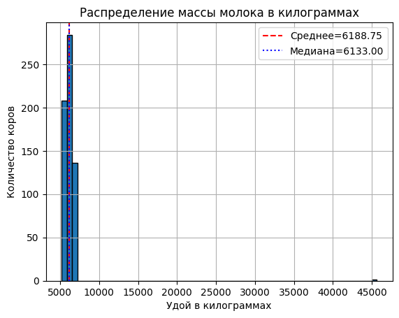

```
(<matplotlib.legend.Legend at 0x227ab24ad90>, None)
```

```python
# напишем функцию для построения гистограммы по столбцам датафрейма
def histogram_creation(data, column, value, title, ylabel, xlabel):
    data[column].hist(edgecolor='black', bins=value)
    plt.title(title)
    plt.ylabel(ylabel)
    plt.xlabel(xlabel)
    column_mean = data[column].mean()
    column_median = data[column].median()
    plt.axvline(
    column_mean,
    color='red',
    linestyle='dashed',
    label=f'Среднее={column_mean:.2f}'
    )
    plt.axvline(
    column_median,
    color='blue',
    linestyle='dotted',
    label=f'Медиана={column_median:.2f}'
    )
    return plt.legend(), plt.show()

# вызовем функцию
histogram_creation(ferma_main, 'удой_кг', 60, 'Распределение массы молока в килограммах', 'Количество коров', 'Удой в килограммах')
```

- За год коровы дают приблизительно от **5 000** до **7 500** килограмм молока.
- Среднее значение — **6 188.75** практически совпадает с медианным — **6 133**.
- Заметна концентрация значений у отметки в примерно **6 500** килограмм, а также отдельное крупное значение у отметки в **45 000** килограмм.

Ознакомимся с числовым описанием данных столбца:

```python
# выведем числовое описание данных
ferma_main['удой_кг'].describe()
```

```
count      629.000000
mean      6188.750397
std       1644.795489
min       5204.000000
25%       5751.000000
50%       6133.000000
75%       6501.000000
max      45616.000000
Name: удой_кг, dtype: float64
```

- Минимальное значение — **5 204** кг выглядит реалистично.
- Максимальное значение — **45 616** кг превышает среднее примерно в 7 раз. Мы также можем увидеть его на гистограмме выше. Возможно, оно является выбросом.

Проверим столбец на наличие выбросов с помощью диаграммы размаха:

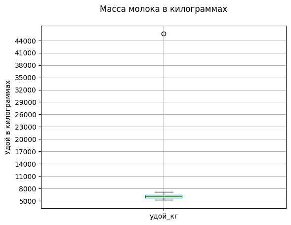

```python
# напишем функцию для построения диаграммы размаха
def boxplot_creation(data, column, title, ylabel, value_1, value_2, value_3):
    data.boxplot(column=column)
    plt.title(title, pad=20)
    plt.ylabel(ylabel)
    plt.yticks(range(value_1, value_2, value_3))
    return plt.show()

# вызовем функцию
boxplot_creation(ferma_main, 'удой_кг', 'Масса молока в килограммах', 'Удой в килограммах', 5000, 45616, 3000 )
```

- На диаграмме заметен выброс у отметки в **45 000** кг.

Рассчитаем межквартильный размах и отфильтруем данные по верхней границе выбросов:

```python
# напишем функцию для расчёта межквартильного размаха
# расчитаем верхнюю и нижнюю границы нормального размаха
def emission_limit(data, column):
    Q1 = data[column].quantile(0.25)
    Q3 = data[column].quantile(0.75)
    IQR = Q3 - Q1
    upper_limit = Q3 + 1.5 * IQR
    lower_limit = Q1 - 1.5 * IQR
    result= print(
        f"Верхняя граница выбросов = {upper_limit:.2f}\nНижняя граница выбросов = {lower_limit:.2f}")
    return result

# вызовем функцию
emission_limit(ferma_main, 'удой_кг')
```

```
Верхняя граница выбросов = 7626.00
Нижняя граница выбросов = 4626.00
```

```python
# сохраним копию исходного датафрейма
good_ferma_main = ferma_main.copy()

# отфильтруем данные по верхней границе
good_ferma_main = good_ferma_main.query('удой_кг <= 7626.00')

# проверим результат
good_ferma_main['удой_кг'].sort_values(ascending=False).head(10)
```

```
70     7222
135    7207
296    7201
294    7197
593    7174
46     7173
176    7141
264    7133
503    7113
194    7113
Name: удой_кг, dtype: int64
```

Построим гистограмму для анализа распределения количественных признаков в столбце `эке` с показателем питательности корма коровы:

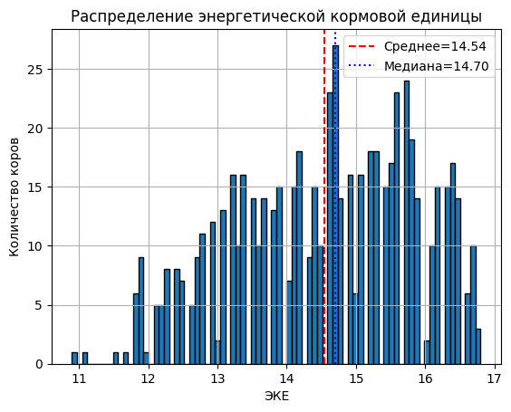

```
(<matplotlib.legend.Legend at 0x227ab4dfd00>, None)
```

```python
# вызовем функцию для построения гистограммы
histogram_creation(ferma_main, 'эке', 80, 'Распределение энергетической кормовой единицы', 'Количество коров', 'ЭКЕ')
```

- Распределение асимметрично, среднее смещено влево от медианы.
- Большинство значений сосредоточено справа. Слева можно заметить несколько значений, близких к минимальному. Можно предположить, что это аномалии.

Ознакомимся с минимальным значением:

```python
# выведем минимальное значение с помощью min()
ferma_main['эке'].min()
```

```
10.9
```

Проверим, содержат ли данные выбросы:

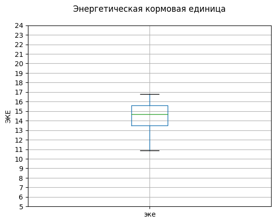

```python
# вызовем функцию для построения диаграммы размаха
boxplot_creation(ferma_main, 'эке', 'Энергетическая кормовая единица', 'ЭКЕ', 5, 25, 1)
```

- "Ящик с усами" показывает отсутствие выбросов у нижней и верхней границ.

Убедимся, что в данных действительно нет выбросов. Рассчитаем верхнюю и нижнюю границы нормального размаха:

```python
# вызовем функцию для расчёта межквартильного размаха
emission_limit(ferma_main, 'эке')
```

```
Верхняя граница выбросов = 18.75
Нижняя граница выбросов = 10.35
```

Значения лежат внутри диапазона верхней и нижней границ. Значит, в столбце действительно отсутствуют выбросы.

Построим гистограмму для анализа распределения количественных признаков в столбце `сырой_протеин_г`:

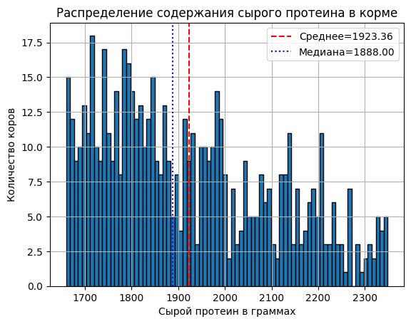

```
(<matplotlib.legend.Legend at 0x227ab79bd30>, None)
```

```python
# вызовем функцию для построения гистограммы
histogram_creation(ferma_main, 'сырой_протеин_г', 80, 'Распределение содержания сырого протеина в корме', 'Количество коров', 'Сырой протеин в граммах')
```

- Значения распределены с асимметрией вправо. Среднее больше медианы.

Посмотрим, есть ли в столбце выбросы. Построим диаграмму размаха:

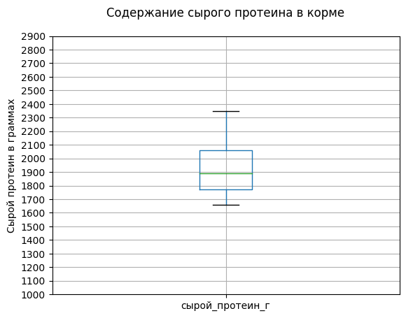

```python
# вызовем функцию для построения диаграммы размаха
boxplot_creation(ferma_main, 'сырой_протеин_г', 'Содержание сырого протеина в корме', 'Сырой протеин в граммах', 1000, 3000, 100)
```

- Диаграмма показывает, что в столбце отсутствуют аномальные значения.

Рассчитаем верхнюю и нижнюю границы нормального рахмаха:

```python
# вызовем функцию для расчёта межквартильного размаха
emission_limit(ferma_main, 'сырой_протеин_г')
```

```
Верхняя граница выбросов = 2498.50
Нижняя граница выбросов = 1334.50
```

Значения находятся в диапазоне верхней и нижней границ. Значит, в столбце действительно отсутствуют выбросы.

Построим гистограмму для анализа распределения количественных признаков в столбце `спо` c cахаро-протеиновым соотношением в корме коровы:

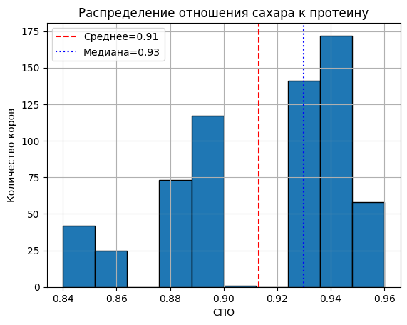

```
(<matplotlib.legend.Legend at 0x227ab938bb0>, None)
```

```python
# вызовем функцию для построения гистограммы
histogram_creation(ferma_main, 'спо', 10, 'Распределение отношения сахара к протеину', 'Количество коров', 'СПО')
```

- Распределение асимметрично. Среднее смещено влево от медианы.
- Значения распределены неравномерно: большинство коров получает корм с соотношением сахара к протеину в диапазоне от **0.92** до **0.96**. При этом можно заметить тонкий "хвост" в диапазоне приблизительно от **0.90** до **0.91**.

Проверим данные на наличие выбросов:

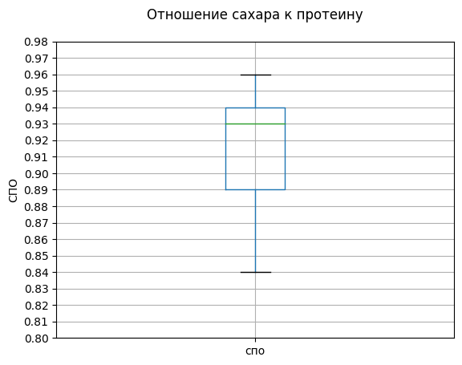

```python
# напишем функцию для построения диаграммы размаха с учетом вещественных чисел
def boxplot_creation_float(data, column, title, ylabel, value_1, value_2, value_3):
    data.boxplot(column=column)
    plt.title(title, pad=20)
    plt.ylabel(ylabel)
    plt.yticks(np.arange(value_1, value_2, value_3))

# вызовем функцию
boxplot_creation_float(ferma_main, 'спо', 'Отношение сахара к протеину', 'СПО', 0.80, 0.99, 0.01)
```

- Согласно диаграмме, в столбце отсутствуют выбросы.

Рассчитаем границы нормального размаха:

```python
# вызовем функцию для расчёта межквартильного размаха
emission_limit(ferma_main, 'спо')
```

```
Верхняя граница выбросов = 1.01
Нижняя граница выбросов = 0.82
```

Значения входят в диапазон верхней и нижней границ. Выбросы в столбце отсутствуют.

Построим гистограмму для анализа распределения количественных признаков в столбце `жирность_%` с содержанием жиров в молоке:

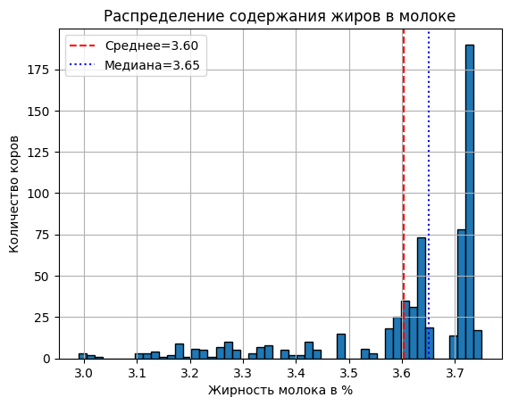

```
(<matplotlib.legend.Legend at 0x227ab7a9f70>, None)
```

```python
# вызовем функцию для построения гистограммы
histogram_creation(ferma_main, 'жирность_%', 50, 'Распределение содержания жиров в молоке', 'Количество коров', 'Жирность молока в %')
```

- На графике заметна асимметрия распределения: среднее смещено влево относительно медианы.
- Самое большое количество значений сконцентрировано приблизительно у отметки в **3.7** %.
- Видно несколько небольших значений у отметки **3.0**. Можно предположить, что это выбросы.

Проверим, содержит ли столбец выбросы:

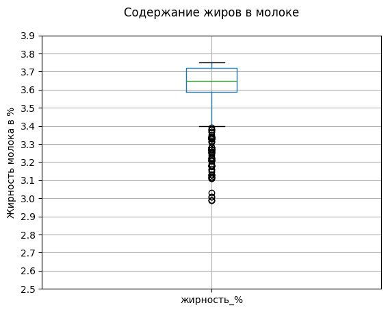

```python
# вызовем функцию для построения диаграммы размаха с учётом вещественных чисел
boxplot_creation_float(ferma_main, 'жирность_%', 'Содержание жиров в молоке', 'Жирность молока в %', 2.5, 4.0, 0.1)
```

- Диаграмма размаха показывает выбросы за пределами нижнего "уса" — приблизительно от отметки **3.4** % до **3.0** %.

Рассчитаем межквартильный размах:

```python
# вызовем функцию для расчёта межквартильного размаха
emission_limit(ferma_main, 'жирность_%')
```

```
Верхняя граница выбросов = 3.92
Нижняя граница выбросов = 3.39
```

Отфильтруем данные по нижней границе нормального размаха:

```python
# отфильтруем данные по нижней границе с помощью query()
good_ferma_main = good_ferma_main.query('`жирность_%` >= 3.39')

# проверим результат
good_ferma_main['жирность_%'].sort_values(ascending=False).head(10)
```

```
204    3.75
181    3.74
270    3.74
308    3.74
249    3.74
318    3.74
339    3.74
141    3.74
28     3.74
208    3.74
Name: жирность_%, dtype: float64
```

Построим гистограмму для анализа распределения количественных признаков в столбце `белок_%` с содержанием белков в молоке:

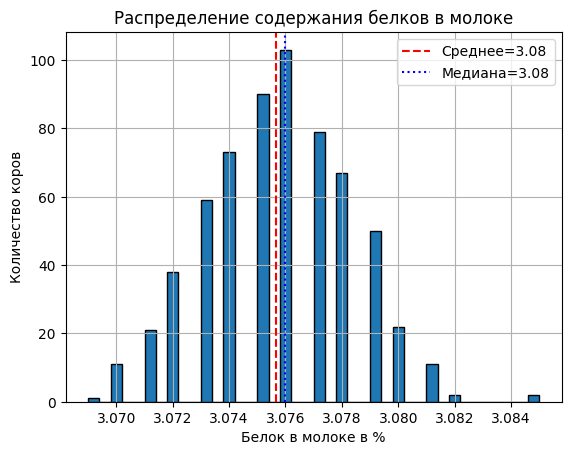

```
(<matplotlib.legend.Legend at 0x227ab7cbcd0>, None)
```

```python
# вызовем функцию для построения гистограммы
histogram_creation(ferma_main, 'белок_%', 40, 'Распределение содержания белков в молоке', 'Количество коров', 'Белок в молоке в %')
```

- Гистограмма показывает нормальное распределение.
- Среднее и медианное значения совпадают — **3.08** %.
- Справа можно заметить особенно высокое значение приблизительно у отметки в **3.084** %. Можно предположить, что это выброс.

Проверим, является ли значение выбросом:

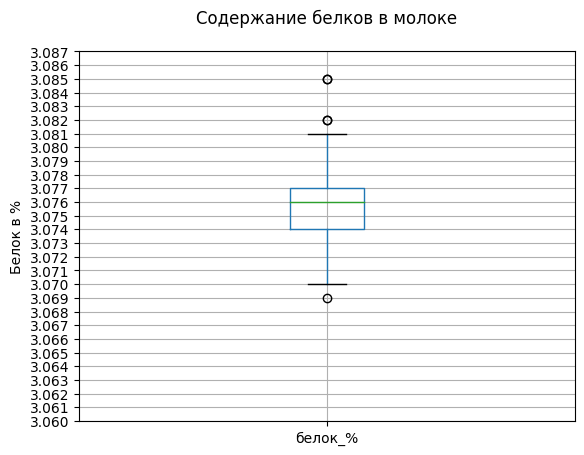

```python
# вызовем функцию для построения диаграммы размаха с учетом вещественных чисел
boxplot_creation_float(ferma_main, 'белок_%', 'Содержание белков в молоке', 'Белок в %', 3.06, 3.087, 0.001)
```

- Диаграмма показывает, что в столбце есть аномальные значения за пределами верхнего и нижнего "уса" — приблизительно у отметок **3.069** %, **3.082** % и **3.085** %.

Рассчитаем межквартильный рахмах и очистим данные от аномалий для более корректного анализа в дальнейшем:

```python
# вызовем функцию для расчёта межквартильного размаха, верхней и нижней границ нормального размаха
emission_limit(ferma_main, 'белок_%')
```

```
Верхняя граница выбросов = 3.08
Нижняя граница выбросов = 3.07
```

```python
# отфильтруем данные по верхней и нижней границам с помощью query()
good_ferma_main = good_ferma_main.query('`белок_%` >= 3.07 and `белок_%` <= 3.08')
```

```python
# проверим результат
good_ferma_main['белок_%'].sort_values(ascending=False).head(10)
```

```
171    3.08
68     3.08
549    3.08
485    3.08
366    3.08
54     3.08
450    3.08
122    3.08
156    3.08
198    3.08
Name: белок_%, dtype: float64
```

```python
# проверим результат
good_ferma_main['белок_%'].sort_values().head(10)
```

```
336    3.07
533    3.07
418    3.07
303    3.07
84     3.07
552    3.07
326    3.07
258    3.07
259    3.07
347    3.07
Name: белок_%, dtype: float64
```

Проанализируем категориальные пременные в столбце `порода` с помощью столбчатой диаграммы:

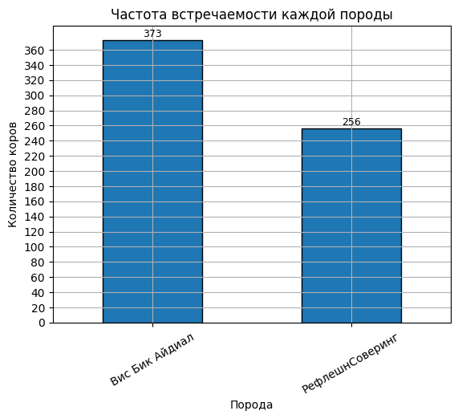

```python
# напишем функцию для построения столбчатой диаграммы
def bar_plot(data, column, title, xlabel, ylabel, value_1, value_2, value_3):
    value_counts_bar = data[column].value_counts()
    value_counts_bar.plot(kind='bar', edgecolor='black')
    for i, value in enumerate(value_counts_bar):
        plt.text(i, value+1, str(value), ha='center', va='bottom', fontsize=9)
    plt.title(title)
    plt.xlabel(xlabel)
    plt.xticks(rotation=30)
    plt.yticks(range(value_1, value_2, value_3))
    plt.ylabel(ylabel)
    plt.grid(True)
    return plt.show()

# вызовем функцию
bar_plot(ferma_main, 'порода', 'Частота встречаемости каждой породы', 'Порода', 'Количество коров', 0, 370, 20)
```

- На диаграмме видно, что порода `Вис Бик Айдал` встречается чаще остальных — **373** особи. На втором месте коровы породы Рефлекшн Соверинг — **256**.
- Можно предположить, что у фермы в приоритете разведение породы `Вис Бик Айдал`. Вероятно, из-за более высоких показателей молочной продуктивности или лучшего вкуса молока.

Проанализируем категориальные пременные в столбце `тип_пастбища` с помощью столбчатой диаграммы:

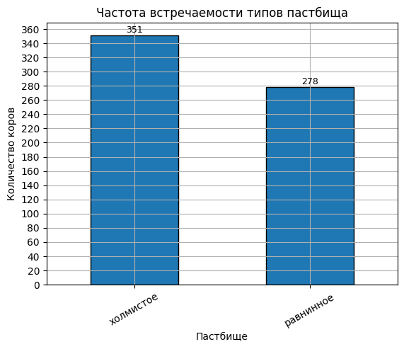

```python
# вызовем функцию для построения столбчатой диаграммы
bar_plot(ferma_main, 'тип_пастбища', 'Частота встречаемости типов пастбища', 'Пастбище', 'Количество коров', 0, 370, 20)
```

- Согласно диаграмме, большинство коров фермера пасётся на холмистом пастбище — **351**. Возможно, ландшафт влияет на вкус молока.

Проанализируем категориальные пременные в столбце `порода_папы_быка` с помощью столбчатой диаграммы:

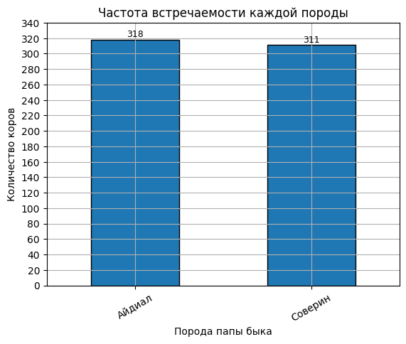

```python
# вызовем функцию для построения столбчатой диаграммы
bar_plot(ferma_main, 'порода_папы_быка', 'Частота встречаемости каждой породы', 'Порода папы быка', 'Количество коров', 0, 360, 20)
```

- Обе породы папы быка встречаются в датафрейме практически одинаково часто.

Проанализируем категориальные пременные в столбце `вкус_молока` с помощью столбчатой диаграммы:

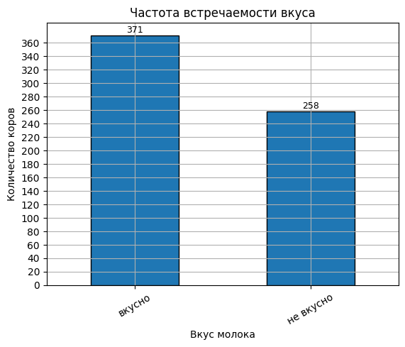

```python
# вызовем функцию для построения столбчатой диаграммы
bar_plot(ferma_main, 'вкус_молока', 'Частота встречаемости вкуса', 'Вкус молока', 'Количество коров', 0, 380, 20)
```

- В датафрейме чаще встречаются коровы, которые дают вкусное молоко — **371**.

Проанализируем категориальные пременные в столбце `возраст` с помощью столбчатой диаграммы:

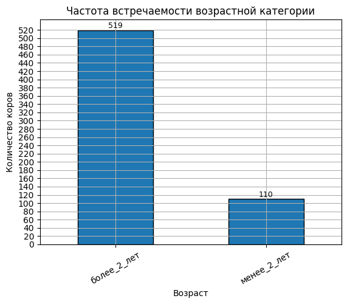

```python
# вызовем функцию для построения столбчатой диаграммы
bar_plot(ferma_main, 'возраст', 'Частота встречаемости возрастной категории', 'Возраст', 'Количество коров', 0, 530, 20)
```

- В таблице представлено почти в 5 раз больше коров в возрастной категории `более 2 лет`, чем в `менее 2 лет`. Это можно объяснить тем, что коровы начинают давать молоко в возрасте примерно `от 1,5 до 2 лет`.

### Статистический анализ данных в ferma_dad

Построим столбчатую диаграмму для анализа распределения качественных переменных в столбце `имя_папы`:

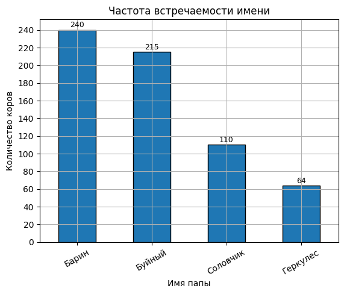

```python
# вызовем функцию для построения столбчатой диаграммы
bar_plot(ferma_dad, 'имя_папы', 'Частота встречаемости имени', 'Имя папы', 'Количество коров', 0, 260, 20)
```

- Чаще всего в датафрейме встречается имя `Барин` - **240** раз.
- Реже всего встречается имя `Геркулес` — всего **64** раза.

### Статистический анализ данных в cow_buy

Построим гистограмму для анализа распределения количественных признаков в столбце `текущая_жирность_%`:

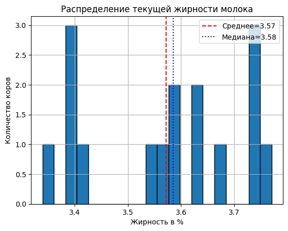

```
(<matplotlib.legend.Legend at 0x227ac3df8e0>, None)
```

```python
# вызовем функцию для построения гистограммы
histogram_creation(cow_buy, 'текущая_жирность_%', 20, 'Распределение текущей жирности молока', 'Количество коров', 'Жирность в %')
```

- Среднее и медиана практически совпадают — **3.57** и **3.58**.
- Гистограмма показывает два узких пика у отметок приблизительно в **3.4** % и **3.75** %.

Проверим данные на наличие выбросов:

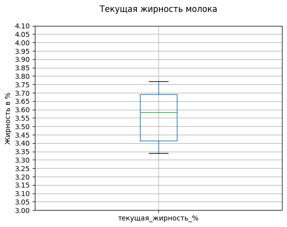

```python
# вызовем функцию для построения диаграммы размаха
boxplot_creation_float(cow_buy,'текущая_жирность_%', 'Текущая жирность молока', 'Жирность в %', 3.00, 4.11, 0.05)
```

- Согласно диаграмме, в данных отсутсвуют выбросы.

Рассчитаем межквартильный размах:

```python
# вызовем функцию для расчёта межквартильного размаха, верхней и нижней границ нормального размаха
emission_limit(cow_buy, 'текущая_жирность_%')
```

```
Верхняя граница выбросов = 4.11
Нижняя граница выбросов = 3.00
```

Значения находятся в пределах диапазона верхней и нижней границ. Аномалии в столбце отсутствуют.

Построим гистограмму для анализа распределения количественных признаков в столбце `текущий_уровень_белок_%`:

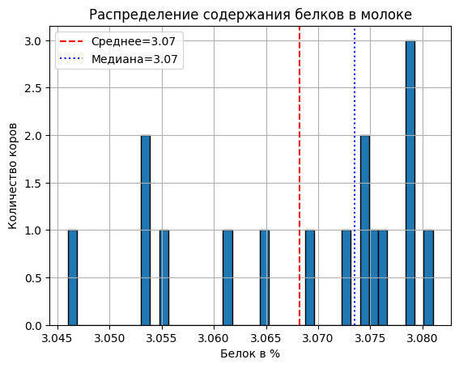

```
(<matplotlib.legend.Legend at 0x227ac6b76a0>, None)
```

```python
# вызовем функцию для построения гистограммы
histogram_creation(cow_buy, 'текущий_уровень_белок_%', 40, 'Распределение содержания белков в молоке', 'Количество коров', 'Белок в %')
```

- Среднее и медианное значения совпадают — **3.07** %.
- Можно заметить концентрацию значений у отметки приблизительно в **3.080** %.

Проверим данные на выбросы:

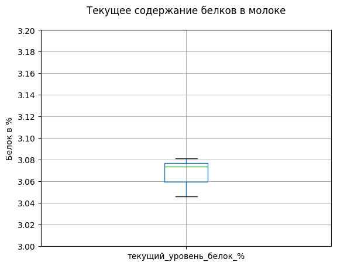

```python
# вызовем функцию для построения диаграммы размаха
boxplot_creation_float(cow_buy, 'текущий_уровень_белок_%', 'Текущее содержание белков в молоке', 'Белок в %', 3.0, 3.20, 0.02)
```

- Диаграмма размаха показывает отсутствие аномальных значений в столбце.

Рассчитаем межквартильный размах:

```python
# вызовем функцию для расчёта межквартильного размаха, верхней и нижней границ нормального размаха
emission_limit(cow_buy, 'текущий_уровень_белок_%')
```

```
Верхняя граница выбросов = 3.10
Нижняя граница выбросов = 3.03
```

Значения в столбце находятся в пределах этого диапазона. В данных отсутствуют выбросы.

Построим столбчатую диаграмму для анализа распределения качественных переменных в столбце `порода`:

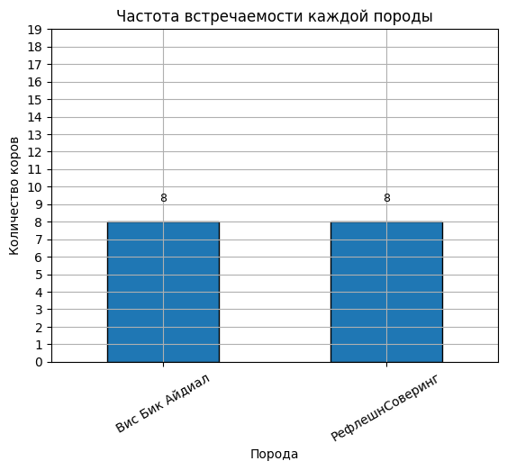

```python
# вызовем функцию для построения столбчатой диаграммы
bar_plot(cow_buy, 'порода', 'Частота встречаемости каждой породы', 'Порода', 'Количество коров', 0, 20, 1)
```

- В датафрейме представлено одинаковое количество коров обеих пород.

Построим столбчатую диаграмму для анализа распределения качественных переменных в столбце `тип_пастбища`:

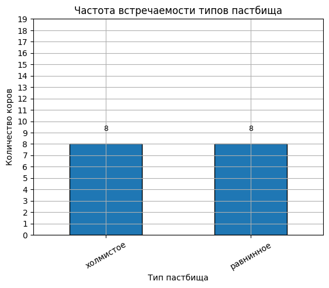

```python
# вызовем функцию для построения столбчатой диаграммы
bar_plot(cow_buy, 'тип_пастбища', 'Частота встречаемости типов пастбища', 'Тип пастбища', 'Количество коров', 0, 20, 1)
```

- Диаграмма показывает одинаковое количество коров, пасущихся на `равнинном` и `холмистом` пастбищах.

Построим столбчатую диаграмму для анализа распределения качественных переменных в столбце `порода_папы_быка`:

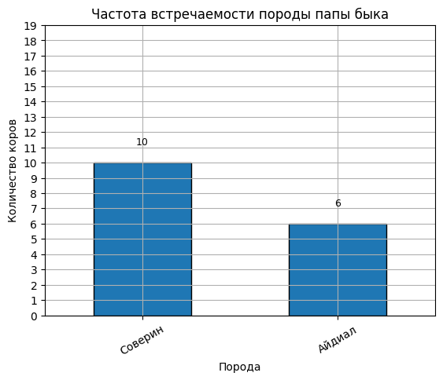

```python
# вызовем функцию для построения столбчатой диаграммы
bar_plot(cow_buy, 'порода_папы_быка', 'Частота встречаемости породы папы быка', 'Порода', 'Количество коров', 0, 20, 1)
```

- Преобладает количество коров с породой папы быка `Соверин`.

Построим столбчатую диаграмму для анализа распределения качественных переменных в столбце `имя_папы`:

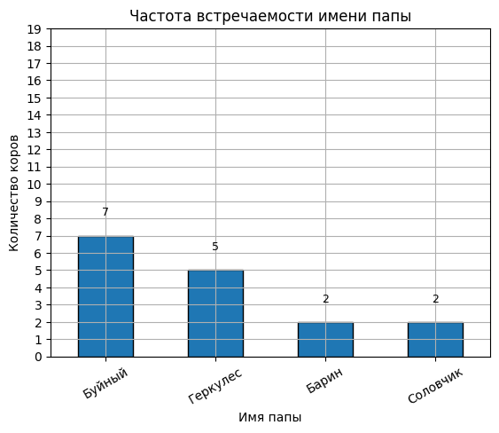

```python
# вызовем функцию для построения столбчатой диаграммы
bar_plot(cow_buy, 'имя_папы', 'Частота встречаемости имени папы', 'Имя папы', 'Количество коров', 0, 20, 1)
```

Построим столбчатую диаграмму для анализа распределения качественных переменных в столбце `возраст`:

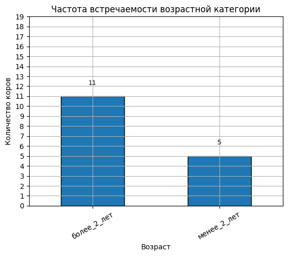

```python
# вызовем функцию для построения столбчатой диаграммы
bar_plot(cow_buy, 'возраст', 'Частота встречаемости возрастной категории', 'Возраст', 'Количество коров', 0, 20, 1)
```

- Количество коров в возрасте `более 2 лет` почти в два раза превышает количество коров в возрасте `менее 2 лет`.

**Выводы:**

- Обнаружили и устранили выбросы в датафрейме `ferma_main` в столбцах `удой_кг`, `жирность_%` и `белок_%`.
- Создали копию исходного датафрейма с очищенными данными — `good_ferma_main`.
- В датафрейме `cow_buy` В стобцах с числовыми значениями отсутствуют аномалии.

### Корреляционный анализ признаков в good_ferma_main

Рассчитаем коэффициенты корреляции между всеми числовыми признаками:

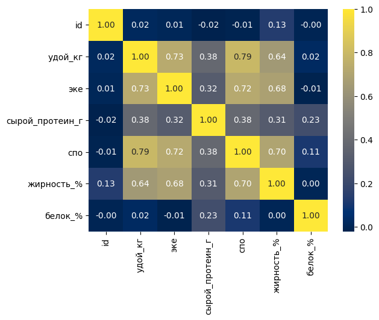

```python
# выведем матрицу корреляций между признаками
# оставим только числовые признаки
numeric_data = good_ferma_main.select_dtypes(include='number')
sns.heatmap(numeric_data.corr(), annot=True, fmt='.2f', cmap='cividis')
```

- Целевой признак `удой_кг` для модели линейной регрессии коррелирует с входными признаками:`эке` — **0.73**, `сырой_протеин_г`— **0.38**, `спо` — **0.79** и `жирность_%` — **0.64**.

Рассчитаем корреляцию всех входных признаков датафрейма с помощью `phik_matrix`:

```python
# рассчитаем корреляцию всех числовых признаков
good_ferma_phik = good_ferma_main.phik_matrix()

good_ferma_phik
```

```
interval columns not set, guessing: ['id', 'удой_кг', 'эке', 'сырой_протеин_г', 'спо', 'жирность_%', 'белок_%']
```

|  | id | удой_кг | эке | сырой_протеин_г | спо | порода | тип_пастбища | порода_папы_быка | жирность_% | белок_% | вкус_молока | возраст |
| --- | --- | --- | --- | --- | --- | --- | --- | --- | --- | --- | --- | --- |
| id | 1.000000 | 0.000000 | 0.082231 | 0.029658 | 0.383800 | 0.645468 | 0.000000 | 0.275790 | 0.534454 | 0.138870 | 0.000000 | 0.000000 |
| удой_кг | 0.000000 | 1.000000 | 0.705925 | 0.401074 | 0.667769 | 0.120376 | 0.264986 | 0.570565 | 0.555377 | 0.150129 | 0.129456 | 0.998854 |
| эке | 0.082231 | 0.705925 | 1.000000 | 0.375474 | 0.608007 | 0.147609 | 0.153956 | 0.127968 | 0.587602 | 0.082130 | 0.295919 | 0.764615 |
| сырой_протеин_г | 0.029658 | 0.401074 | 0.375474 | 1.000000 | 0.352183 | 0.000000 | 0.104085 | 0.000000 | 0.231308 | 0.227214 | 0.128938 | 0.218837 |
| спо | 0.383800 | 0.667769 | 0.608007 | 0.352183 | 1.000000 | 0.168303 | 0.163076 | 0.488204 | 0.614056 | 0.113184 | 0.581643 | 0.730832 |
| порода | 0.645468 | 0.120376 | 0.147609 | 0.000000 | 0.168303 | 1.000000 | 0.180793 | 0.044144 | 0.258470 | 0.383486 | 0.000000 | 0.079707 |
| тип_пастбища | 0.000000 | 0.264986 | 0.153956 | 0.104085 | 0.163076 | 0.180793 | 1.000000 | 0.000000 | 0.000000 | 0.200478 | 0.197837 | 0.039210 |
| порода_папы_быка | 0.275790 | 0.570565 | 0.127968 | 0.000000 | 0.488204 | 0.044144 | 0.000000 | 1.000000 | 0.126341 | 0.124268 | 0.000000 | 0.355113 |
| жирность_% | 0.534454 | 0.555377 | 0.587602 | 0.231308 | 0.614056 | 0.258470 | 0.000000 | 0.126341 | 1.000000 | 0.000000 | 0.140950 | 0.395218 |
| белок_% | 0.138870 | 0.150129 | 0.082130 | 0.227214 | 0.113184 | 0.383486 | 0.200478 | 0.124268 | 0.000000 | 1.000000 | 0.122641 | 0.000000 |
| вкус_молока | 0.000000 | 0.129456 | 0.295919 | 0.128938 | 0.581643 | 0.000000 | 0.197837 | 0.000000 | 0.140950 | 0.122641 | 1.000000 | 0.047943 |
| возраст | 0.000000 | 0.998854 | 0.764615 | 0.218837 | 0.730832 | 0.079707 | 0.039210 | 0.355113 | 0.395218 | 0.000000 | 0.047943 | 1.000000 |

Визуализируем полученный результат с помощью тепловой карты для более комфортного восприятия:

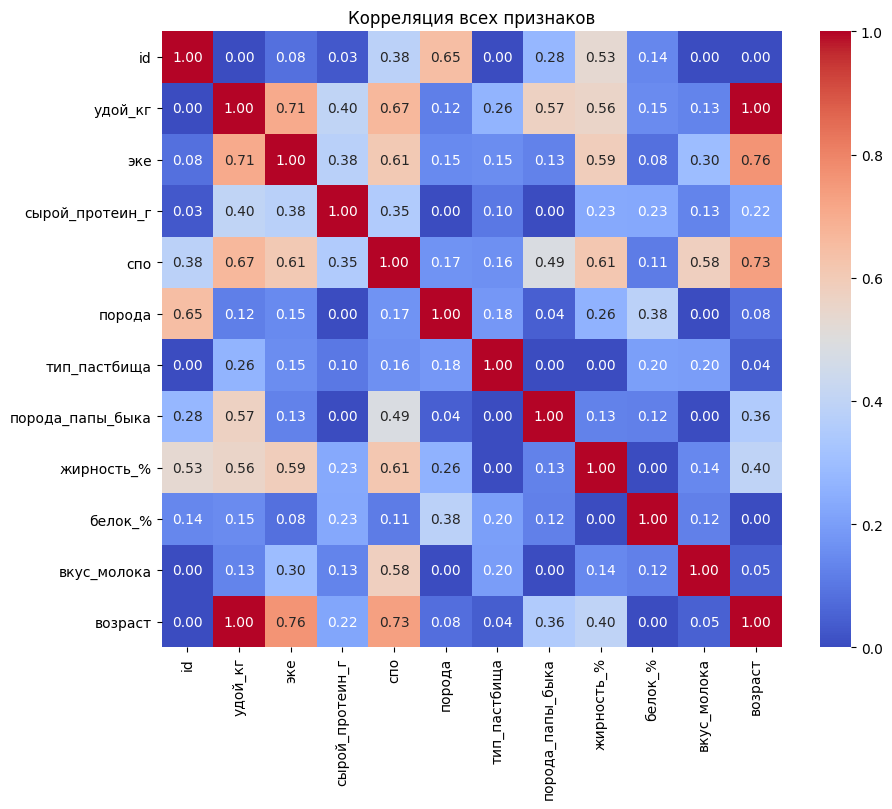

```python
# построим тепловую карту
plt.figure(figsize=(10,8))
sns.heatmap(good_ferma_phik, annot=True, fmt='.2f', cmap="coolwarm", vmin=0, vmax=1)
plt.title('Корреляция всех признаков')
plt.show()
```

- Целевой признак `удой_кг` для модели линейной регрессии также коррелирует с категориальными признаками:`порода_папы_быка` — **0.57** и `возраст` — **1**.
- Целевой признак `вкус_молока` для модели логистической регрессии коррелирует с `спо`(сахаро-протеиновое соотношение) — **0.58**.